# MUSA508 Final Project: NJ Transit Delay Prediction

Juliana Zhou & Julian Hartwell

December 14, 2020

# 1 Introduction

Train delays can be expensive and disruptive events. As the transportation system with the second highest ridership in the country, delays on NJ Transit lines can be particularly disruptive. Unfortunately NJ Transit is also particularly beleaguered by delays, in part due to the advanced average age of its rolling stock. In this analysis, we hope to predict significant train delays within the NJ Transit system. The use case is to build a dashboard meant to assist senior executives making resource distribution decisions (e.g., engineer staffing, train repair scheduling). In the future, with this applied analysis, NJ Transit could hypothetically determine which stations are likely to experience significant delays and have mechanics and shuttle busses on standby to address delays without inconveniencing commuters.

[Link to project pecha kucha presentation](https://www.youtube.com/watch?v=2RC908M7eVY)

# 2 Setup:

```r
knitr::opts_chunk$set(
  comment = NA,
    message = FALSE,
    warning = FALSE)# --- Setup: Libraries ----
# create notin operator
`%notin%` <- Negate(`%in%`)

#remove scientific notation
options(scipen=999)

## Download + Load Packages
pckgs <- c("tidyverse", "kableExtra", "readr", "ggplot2", "lubridate","sf",
           "riem","tigris", "gganimate","gridExtra","knitr","tidyr","caret","viridis")

if (any(pckgs %notin% rownames(installed.packages())==TRUE)){
  install.packages(pckgs, repos = c(CRAN = "http://cloud.r-project.org"))}

lapply(pckgs, FUN = require, character.only = TRUE)

# --- Setup: Aesthetics & Functions ----
mapTheme <- function(base_size = 12) {
  theme(
    text = element_text( color = "black"),
    plot.title = element_text(size = 14,colour = "black"),
    plot.subtitle=element_text(face="italic"),
    plot.caption=element_text(hjust=0),
    axis.ticks = element_blank(),
    panel.background = element_blank(),axis.title = element_blank(),
    axis.text = element_blank(),
    axis.title.x = element_blank(),
    axis.title.y = element_blank(),
    panel.grid.minor = element_blank(),
    panel.border = element_rect(colour = "black", fill=NA, size=2)
  )
}

plotTheme <- function(base_size = 12) {
  theme(
    text = element_text( color = "black"),
    plot.title = element_text(size = 14,colour = "black"),
    plot.subtitle = element_text(face="italic"),
    plot.caption = element_text(hjust=0),
    axis.ticks = element_blank(),
    panel.background = element_blank(),
    panel.grid.major = element_line("grey80", size = 0.1),
    panel.grid.minor = element_blank(),
    panel.border = element_rect(colour = "black", fill=NA, size=2),
    strip.background = element_rect(fill = "grey80", color = "white"),
    strip.text = element_text(size=12),
    axis.title = element_text(size=12),
    axis.text = element_text(size=10),
    plot.background = element_blank(),
    legend.background = element_blank(),
    legend.title = element_text(colour = "black", face = "italic"),
    legend.text = element_text(colour = "black", face = "italic"),
    strip.text.x = element_text(size = 14)
  )
}

palette5 <- c("#25CB10", "#5AB60C", "#8FA108",   "#C48C04", "#FA7800")
palette4 <- c("#981FAC","#FF006A","#FE4C35","#FE9900")
palette2 <- c("#981FAC","#FF006A")

qBr <- function(df, variable, rnd) {
  if (missing(rnd)) {
    as.character(quantile(round(df[[variable]],0),
                          c(.01,.2,.4,.6,.8), na.rm=T))
  } else if (rnd == FALSE | rnd == F) {
    as.character(formatC(quantile(df[[variable]]), digits = 3),
                 c(.01,.2,.4,.6,.8), na.rm=T)
  }
}

q5 <- function(variable) {as.factor(ntile(variable, 5))}

nn_function <- function(measureFrom,measureTo,k) {
  measureFrom_Matrix <-
    as.matrix(measureFrom)
  measureTo_Matrix <-
    as.matrix(measureTo)
  nn <-
    get.knnx(measureTo, measureFrom, k)$nn.dist
  output <-
    as.data.frame(nn) %>%
    rownames_to_column(var = "thisPoint") %>%
    gather(points, point_distance, V1:ncol(.)) %>%
    arrange(as.numeric(thisPoint)) %>%
    group_by(thisPoint) %>%
    summarize(pointDistance = mean(point_distance)) %>%
    arrange(as.numeric(thisPoint)) %>%
    dplyr::select(-thisPoint) %>%
    pull()

  return(output)
}
```

# 3 Data

The data used in this analysis came from the [Kaggle NJ Transit + Amtrak (NEC) Rail Performance](https://www.kaggle.com/pranavbadami/nj-transit-amtrak-nec-performance) data. Amtrak data was removed for the specifics of this project. Train delay data are captured in separate .csv files by month, from March 2018 to May 2020. In addition to timecodes, the data also contain information on the train ID, departure station, destination station, line, and length of day in minutes of each delay event.

Using these variables, features for rush hour, weekday/weekend, and line origin and final destination stations are also created. Using these features, inclusion features for major hubs along the affected line (i.e., New York Penn Station, Hoboken, Newark) are also determined.

```r
# --- Data ----
### Read in CSV files

files <- list.files(path = "./Raw_Data/",pattern = "*.csv", full.names = T)
data <- sapply(files, read_csv, simplify=FALSE) %>%
  bind_rows(.id = "id")

## NJ Transit only
njtransit <- data %>%
  filter(type == "NJ Transit") %>%
  mutate(id = rownames(.)) %>%
  na.omit()

njtransit$delay_binary <- ifelse(njtransit$delay_minutes >5,1,0)

## Create hour, week, day of the week, and month columns
# Ignoring year - there's only two (2018 & 2019 and I want random test/train splits)
njtransit <- njtransit %>%
  mutate(interval60 = floor_date(ymd_hms(scheduled_time), unit = "hour"),
         interval15 = floor_date(ymd_hms(scheduled_time), unit = "15 mins"),
         year = year(interval60),
         hour = hour(interval60),
         week = week(interval60),
         dotw = wday(interval60, week_start = getOption("lubridate.week.start", 1)),
         month = month(interval60))

# Weekday vs. weekend
# Rush hour between 6am and 10am or 4pm and 8pm
njtransit <- njtransit %>%
  mutate(weekday = ifelse(dotw %in% 1:5,"1","0"),
         rush = ifelse(hour<10 & hour>=6 & weekday=="1","1",
                ifelse(hour<20 & hour>=16 & weekday=="1","1","0")))

# --- Features ----
# Origin & Destination Feature
njtransit <- njtransit %>%
  group_by(train_id) %>%
  arrange(stop_sequence) %>%
  filter(row_number()==1) %>%
  mutate(origin = to) %>%
  select(train_id,origin) %>%
  right_join(njtransit,.,by="train_id") %>%
  group_by(train_id) %>%
  arrange(stop_sequence) %>%
  filter(row_number()==n()) %>%
  mutate(destination = to) %>%
  select(train_id,origin,destination) %>%
  right_join(njtransit,.,by="train_id")

# Includes Manhattan Feature % Line dummies
njtransit <- njtransit %>%
  mutate(incl_manhattan = ifelse(origin == "New York Penn Station","1",ifelse(destination == "New York Penn Station","1","0")),
         incl_hoboken = ifelse(origin == "Hoboken","1",ifelse(destination == "Hoboken","1","0")),
         incl_newark = ifelse(origin == "Newark Penn Station","1",ifelse(destination == "Newark Penn Station","1","0")))
```

## 3.1 Weather & Geographies

Once preliminary features are created, weather information and station geographies are also added. Weather data is taken from a weather station at Newark Airport, and ArcGIS Open Data is used for station geographies.

```r
# Weather Feature
weather.Data <- riem_measures(station = "EWR", date_start = "2018-03-01", date_end = "2020-05-18")

## Plot Newark weather data
weather.Panel <-
  weather.Data %>%
  mutate_if(is.character, list(~replace(as.character(.), is.na(.), "0"))) %>%
  replace(is.na(.), 0) %>%
  mutate(interval60 = floor_date(ymd_h(substr(valid, 1, 13))),
         week = week(interval60),
         dotw = wday(interval60, label=TRUE)) %>%
  group_by(interval60) %>%
  summarize(Temperature = max(tmpf),
            Precipitation = sum(p01i),
            Wind_Speed = max(sknt)) %>%
  mutate(Temperature = ifelse(Temperature == 0, 42, Temperature))

# Join weather data
njtransit <- weather.Panel %>%
  plyr::join(njtransit,.,by="interval60",type="left") %>%
  mutate(weather_na = ifelse(is.na(Temperature), "1",
                      ifelse(is.na(Precipitation), "1",
                      ifelse(is.na(Wind_Speed), "1","0"))))

njtransit[is.na(njtransit)] = 0


### Station geometries
### Used Long Island ESRI which is recommended for NYC
station_geo <- st_read("https://opendata.arcgis.com/datasets/acf1aa71053f4bb48a1aad7034f35e48_3.geojson") %>%
  st_transform('ESRI:102318')

## Prepping for merge
## Removing leading characters from train id(ATIS_ID)
station_geo$ATIS_ID <- gsub("RAIL","",station_geo$ATIS_ID)
station_geo$ATIS_ID <- sub("^0+", "", station_geo$ATIS_ID)

## Recode non-matching IDs
njtransit$to_id <- as.character(njtransit$to_id)

station_geo$to_id <- station_geo$ATIS_ID
station_geo <- station_geo %>%
  mutate(
    to_id = ifelse(to_id=="82", "37169", to_id),
    to_id = ifelse(to_id=="163", "32905", to_id),
    to_id = ifelse(to_id=="65", "32906", to_id),
    to_id = ifelse(to_id=="165", "38081", to_id),
    to_id = ifelse(to_id=="171", "39472", to_id),
    to_id = ifelse(to_id=="164", "37953", to_id),
    to_id = ifelse(to_id=="183", "43298", to_id),
    to_id = ifelse(to_id=="128", "38417", to_id),
    to_id = ifelse(to_id=="167", "38174", to_id),
    to_id = ifelse(to_id=="168", "38187", to_id),
    to_id = ifelse(to_id=="166", "38105", to_id),
    to_id = ifelse(to_id=="172", "39635", to_id),
    to_id = ifelse(STATION=="Wesmont", "43599", to_id))

station_geo <- station_geo %>%
  mutate(
    Lines = ifelse(RAIL_LINE != "Main/Bergen Line" & str_detect(RAIL_LINE, "/"), NA, RAIL_LINE))

# Merge station geographies to njtransit
njtransit_sf <- station_geo %>%
  st_drop_geometry() %>%
  select(LATITUDE, LONGITUDE,STATION,to_id) %>%
  plyr::join(njtransit,.,by="to_id",type="left",match="first") %>%
  mutate(LATITUDE = ifelse(to=="Ramsey Main St", "41.05707", LATITUDE),
         LONGITUDE = ifelse(to=="Ramsey Main St", "-74.14220", LONGITUDE),
         STATION = ifelse(to=="Ramsey Main St", "Ramsey Main St", STATION)) %>%
  st_as_sf(coords = c("LONGITUDE","LATITUDE"), crs=4326, agr = "constant") %>%
  st_transform('ESRI:102318')

#distance to hubs
hub.nyc <-
  filter(station_geo, STATION == "New York Penn Station") %>%
  st_centroid()
hub.hoboken <-
  filter(station_geo, STATION == "Hoboken Terminal") %>%
  slice(n()) %>%
  st_centroid()
hub.newark <-
  filter(station_geo, STATION == "Newark Penn Station") %>%
  slice(n()) %>%
  st_centroid()
hub.secaucus <-
  filter(station_geo, STATION == "Secaucus Junction Upper Level") %>%
  st_centroid()

njtransit_sf <- njtransit_sf %>%
  mutate(distNYC =  as.numeric(st_distance(njtransit_sf,hub.nyc)),
         distHOB =  as.numeric(st_distance(njtransit_sf,hub.hoboken)),
         distEWR =  as.numeric(st_distance(njtransit_sf,hub.newark)),
         distSEC =  as.numeric(st_distance(njtransit_sf,hub.secaucus)))
```

# 4 Exploratory Analyses

To understand the features that affect delays, we did some preliminary analyses to understand how station, weather, and time associate with significant delays.

After looking at average delay by station, we find that all of the stations on the Atlantic City Line how significantly longer average delays than other lines or stations. As it is a clear outlier (spatially), we elected to exclude it from the analysis.

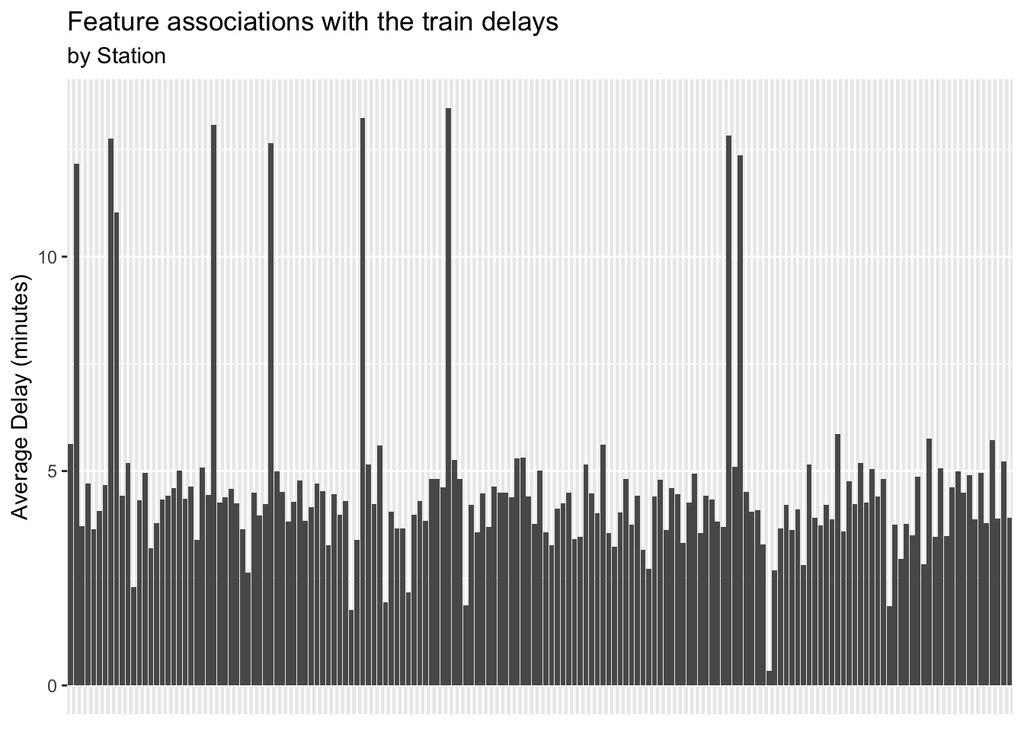

```r
# --- Visualizations ----
## Delay by station - is it consistent?
njtransit_sf %>%
  st_drop_geometry %>%
  group_by(to) %>%
  summarize(mean_delay = mean(delay_minutes)) %>%
  ggplot(., aes(to, mean_delay)) +
  geom_bar(position = "dodge", stat="identity") +
  scale_fill_manual(values = palette2) +
    labs(x="Station", y="Average Delay (minutes)",
       title = "Feature associations with the train delays",
       subtitle = "by Station") +
  theme(axis.title.x=element_blank(),
        axis.text.x=element_blank(),
        axis.ticks.x=element_blank())
```

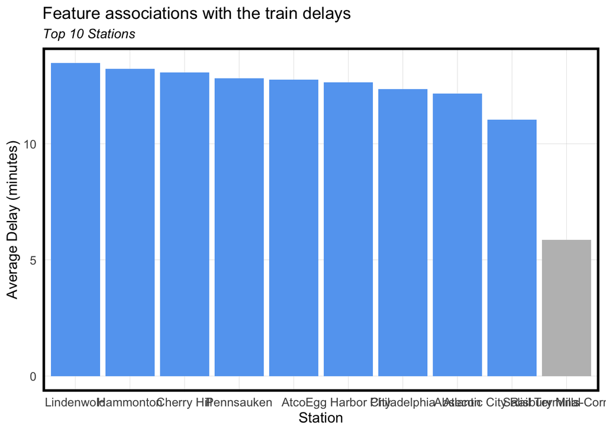

```r
## Delay by station - top 10 largest offenders
njtransit_sf %>%
  st_drop_geometry %>%
  group_by(to) %>%
  summarize(mean_delay = mean(delay_minutes)) %>%
  arrange(desc(mean_delay)) %>%
  slice(1:10) %>%
  ggplot(., aes(x=reorder(to, -mean_delay),y=mean_delay)) +
  geom_bar(aes(fill=to), position = "dodge", stat="identity") +
  scale_fill_manual(values = c("#64a6f1","#64a6f1","#64a6f1","#64a6f1","#64a6f1","#64a6f1","#64a6f1","#64a6f1","#64a6f1","gray")) +
  labs(x="Station", y="Average Delay (minutes)",
       title = "Feature associations with the train delays",
       subtitle = "Top 10 Stations") +
  plotTheme() +
  theme(legend.position = "none")
```

```r
njtransit_sf.clean <- njtransit_sf %>%
  filter(line!="Atl. City Line")
```

## 4.1 Spatial Process

Next, we look at how distance from major transportation hubs like New York Penn Station, Hoboken, Secaucus, and Newark affects average delay.

Our models employ a spatial element that relates the x,y coordinates of each station and their distance to various high-traffic hubs. We hypothesized that busy hubs, like NY Penn Station, Newark Penn Station, Hoboken, etc. would cause inbound and outbound delays. We used `st_distance` to evaluate the distance to each station in meters. This feature was included in our final models.

```r
njCounties <-
  st_read("https://opendata.arcgis.com/datasets/5f45e1ece6e14ef5866974a7b57d3b95_1.geojson") %>%
  st_transform('ESRI:102318')

stations <- njtransit_sf.clean %>%
  group_by(to) %>%
  summarize(mean_delay = mean(delay_minutes))
```

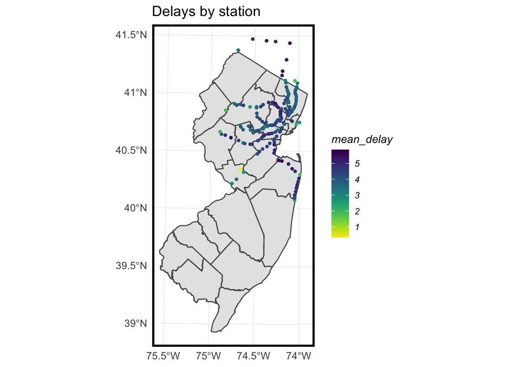

```r
## Delay Map
ggplot() +
  geom_sf(data = njCounties) +
  geom_sf(data = stations, aes(color=mean_delay),
          size=1, show.legend = "point") +
  labs(title= "Delays by station") +
  scale_color_viridis(direction=-1) +
  plotTheme()
```

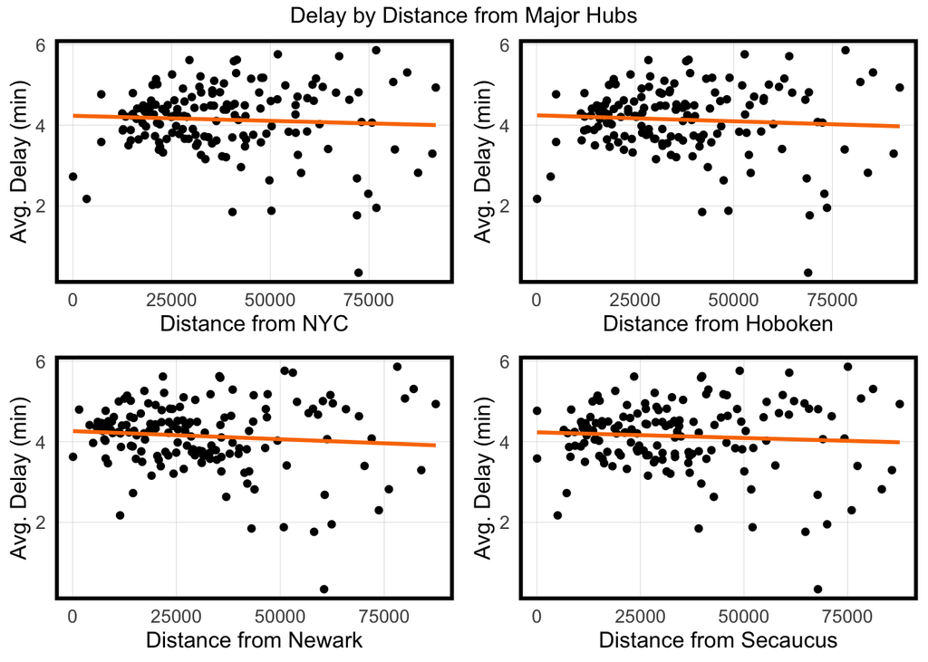

```r
## Distance to Hubs
### Distance to NYC
a <- njtransit_sf.clean %>%
  st_drop_geometry() %>%
  group_by(to) %>%
  summarize(mean_delay = mean(delay_minutes),
            mean_NYCdist = mean(distNYC)) %>%
  ggplot(aes(mean_NYCdist,mean_delay)) +
  geom_point()+
  stat_smooth(aes(mean_NYCdist,mean_delay),
              method = "lm", se = FALSE, size = 1, colour="#FA7800")+
  labs(x="Distance from NYC", y="Avg. Delay (min)") +
  plotTheme()

## Distance to Hoboken
b <- njtransit_sf.clean %>%
  st_drop_geometry() %>%
  group_by(to) %>%
  summarize(mean_delay = mean(delay_minutes),
            mean_HOBdist = mean(distHOB)) %>%
  ggplot(aes(mean_HOBdist,mean_delay)) +
  geom_point()+
  stat_smooth(aes(mean_HOBdist,mean_delay),
              method = "lm", se = FALSE, size = 1, colour="#FA7800")+
  labs(x="Distance from Hoboken", y="Avg. Delay (min)") +
  plotTheme()

## Distance to Newark
c <- njtransit_sf.clean %>%
  st_drop_geometry() %>%
  group_by(to) %>%
  summarize(mean_delay = mean(delay_minutes),
            mean_EWRdist = mean(distEWR)) %>%
  ggplot(aes(mean_EWRdist,mean_delay)) +
  geom_point()+
  stat_smooth(aes(mean_EWRdist,mean_delay),
              method = "lm", se = FALSE, size = 1, colour="#FA7800")+
  labs(x="Distance from Newark", y="Avg. Delay (min)") +
  plotTheme()

## Distance to Secaucus
d <- njtransit_sf.clean %>%
  st_drop_geometry() %>%
  group_by(to) %>%
  summarize(mean_delay = mean(delay_minutes),
            mean_SECdist = mean(distSEC)) %>%
  ggplot(aes(mean_SECdist,mean_delay)) +
  geom_point()+
  stat_smooth(aes(mean_SECdist,mean_delay),
              method = "lm", se = FALSE, size = 1, colour="#FA7800")+
  labs(x="Distance from Secaucus", y="Avg. Delay (min)") +
  plotTheme()

grid.arrange(top = "Delay by Distance from Major Hubs",
             a,b,c,d, layout_matrix = rbind(c(1,2),c(3,4)))
```

## 4.2 Time Lag

There are no time lag features, however we converted our time stamps to calendar features such as hour, month, weekday, etc.

Finally, looking at time, we considered hour of the day (including rush hour effect), day of the week, and month. The evening rush hour appears to cause greater delays than the morning rush hour, through the week, Saturdays appear to have slightly longer average delays, and average delays are greatest during the last two months of the year.

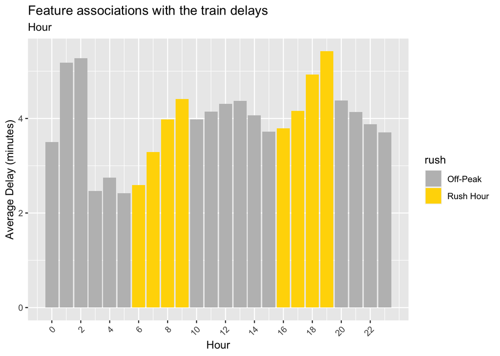

```r
## Delays by Hours & Rush Hour on Weekdays
njtransit_sf.clean %>%
  st_drop_geometry %>%
  filter(weekday==1) %>%
  group_by(hour) %>%
  summarize(mean_delay = mean(delay_minutes)) %>%
  mutate(rush = ifelse(hour<10 & hour>=6,"1",
                ifelse(hour<20 & hour>=16,"1","0"))) %>%
  ggplot(., aes(x=hour, y=mean_delay)) +
  geom_bar(aes(fill = rush), position = "dodge", stat="identity") +
  scale_fill_manual(values = c("gray","gold"),
                    labels= c("Off-Peak","Rush Hour")) +
  scale_x_continuous(breaks=seq(0,23,by=2))+
  labs(x="Hour", y="Average Delay (minutes)",
       title = "Feature associations with the train delays",
       subtitle = "Hour") +
  theme(axis.text.x = element_text(angle = 45, hjust = 1))
```

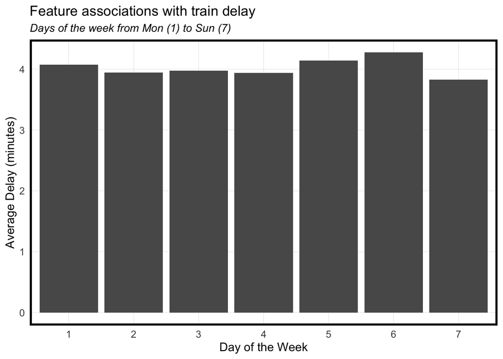

```r
# Day of the Week: More delays on Saturday
njtransit_sf.clean %>%
  st_drop_geometry %>%
  group_by(dotw) %>%
  summarize(mean_delay = mean(delay_minutes)) %>%
  ggplot(aes(dotw, mean_delay)) +
  geom_bar(position = "dodge", stat = "summary", fun = "mean") +
  labs(y="Average Delay (minutes)",
       title = "Feature associations with train delay",
       subtitle = "Days of the week from Mon (1) to Sun (7)") +
  scale_x_discrete(name = "Day of the Week", limits =c('1','2','3','4','5','6','7')) +
  plotTheme()
```

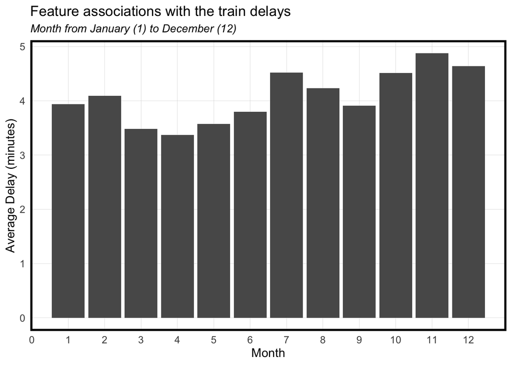

```r
## Month
njtransit_sf.clean %>%
  st_drop_geometry %>%
  group_by(month) %>%
  summarize(mean_delay = mean(delay_minutes)) %>%
  ggplot(., aes(month, mean_delay)) +
  geom_bar(position = "dodge", stat="identity") +
  scale_fill_manual(values = palette5) +
  scale_x_continuous(breaks=seq(0,12,by=1)) +
  labs(x="Month", y="Average Delay (minutes)",
       title = "Feature associations with the train delays",
       subtitle = "Month from January (1) to December (12)") +
  plotTheme()
```

## 4.3 Weather Features

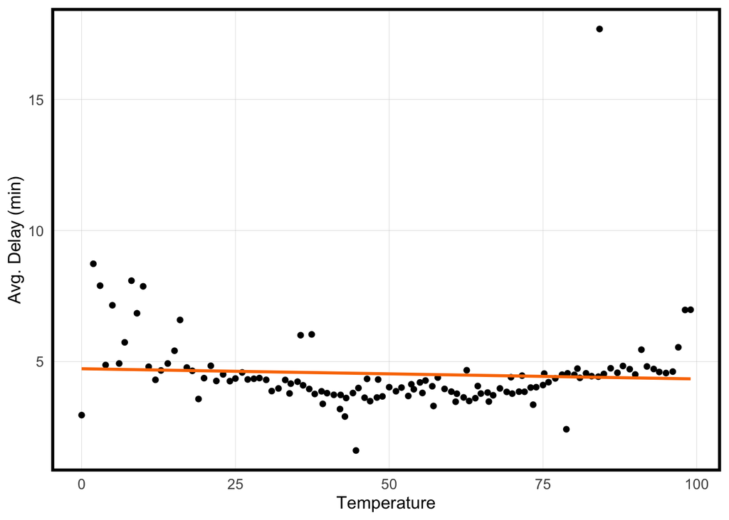

```r
njtransit_sf.clean %>%
  st_drop_geometry() %>%
  group_by(Temperature) %>%
  summarize(mean_delay = mean(delay_minutes)) %>%
  ggplot(aes(Temperature,mean_delay)) +
  geom_point()+
  stat_smooth(aes(Temperature,mean_delay),
              method = "lm", se = FALSE, size = 1, colour="#FA7800")+
  labs(x="Temperature", y="Avg. Delay (min)") +
  plotTheme()
```

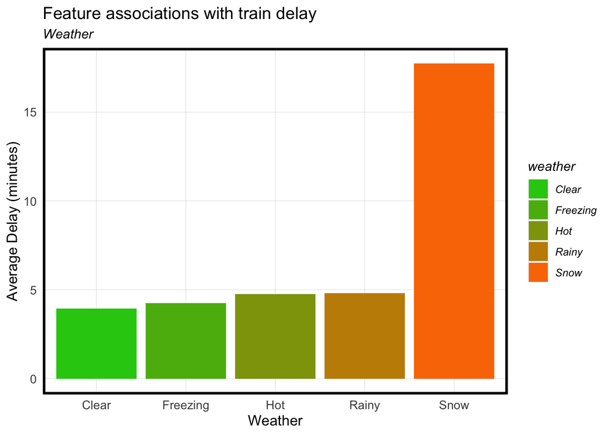

```r
### Recode Weather
njtransit_sf.clean <- njtransit_sf.clean %>%
  mutate(weather = case_when(Temperature <=32 & Precipitation < 1 ~ "Freezing",
                             Temperature <=32 & Precipitation >= 1 ~ "Snow",
                             Temperature >32 & Temperature <85 & Precipitation >=1 ~ "Rainy",
                             Temperature >32 & Temperature <85 & Precipitation <1 ~ "Clear",
                             Temperature >= 85 ~ "Hot"),
         snow = ifelse(Temperature <=32 & Precipitation >= 1, "1", "0"))

njtransit_sf.clean %>%
  st_drop_geometry %>%
  group_by(weather) %>%
  summarize(mean_delay = mean(delay_minutes)) %>%
  ggplot(aes(weather, mean_delay, fill=weather)) +
  geom_bar(position = "dodge", stat = "summary", fun = "mean") +
  scale_fill_manual(values = palette5) +
  labs(x="Weather", y="Average Delay (minutes)",
       title = "Feature associations with train delay",
       subtitle = "Weather") +
  plotTheme()
```

# 5 Modeling

The goal of this next step was to build a model that accurately predicts average station delay minimizing absolute error and absolute percent error. At each stage we removed outliers based on Cook’s Distance which improved our error metrics. Importantly, our data was aggregated at the station-level for our use case.

We used a simple 60/40 train/test split on the aggregated data. Each model has its own unique dataset with increase observations for increasing features.

Model performance was based on out of fold test set predictions. `Model 1` looks solely at calendar features, while `Model 2` looks at calendar and weather features, and `Model 3` examines calendar, weather, and geographic features.

`Model 1` had the lowest absolute error and absolute percent error, but `Model 3` was recommended for the dashboard, given that it is more customizable.

Our use case was designed to predict future station delays. To accomplish this, we had to aggregate our data to represent each station’s average delays given certain features. These models allow us to build a dashboard with certain inputs that can return a risk score for each station on a particular day. Armed with this knowledge, executives at NJ Transit can prepare for delays as they deem fit (more/less trains, staggering to avoid congestion, etc.).

```r
# --- Modeling ----
## model 1 is station + calendar
mod1df <- njtransit_sf.clean %>%
  st_drop_geometry() %>%
  group_by(to,hour,weekday,month) %>%
  summarize(mean_delay = mean(delay_minutes))


mod1df$to <- as.factor(mod1df$to)
mod1df$weekday <- as.factor(mod1df$weekday)
str(mod1df)

set.seed(3457)

inTrain <- createDataPartition(
  y = mod1df$mean_delay,
  p = .60, list = FALSE)
mod1.training <- as.data.frame(mod1df[inTrain,])
mod1.test <- as.data.frame(mod1df[-inTrain,])

model1 <- lm(mean_delay ~ to + hour + weekday + month, data = (mod1.training))

#cooks distance lowers abs error and APE
mod1.training$cd <- cooks.distance(model1)

model1b <- lm(mean_delay ~ to + hour + weekday + month, data = subset(mod1.training, cd<= 4/43135))

mod1.test <-
  mod1.test %>%
  mutate(Regression = "Model 1: Calendar Features",
         Delay.Predict = predict(model1b, mod1.test),
         Delay.Error = Delay.Predict - mean_delay,
         Delay.AbsError = abs(Delay.Predict - mean_delay),
         Delay.APE = (abs(Delay.Predict - mean_delay)) / Delay.Predict)


## Model 2 is station + calendar + weather

mod2df <- njtransit_sf.clean %>%
  st_drop_geometry() %>%
  group_by(to,hour,weekday,month,snow) %>%
  summarize(mean_delay = mean(delay_minutes))

set.seed(3458)

inTrain <- createDataPartition(
  y = mod2df$mean_delay,
  p = .60, list = FALSE)
mod2.training <- as.data.frame(mod2df[inTrain,])
mod2.test <- as.data.frame(mod2df[-inTrain,])

model2 <- lm(mean_delay ~ to + hour + weekday + month + snow, data = (mod2.training))

mod2.training$cd <- cooks.distance(model2)

model2b <- lm(mean_delay ~ to + hour + weekday + month + snow, data = subset(mod2.training, cd<= 4/84524))

mod2.test <-
  mod2.test %>%
  mutate(Regression = "Model 2: Calendar + Snow Features",
         Delay.Predict = predict(model2b, mod2.test),
         Delay.Error = Delay.Predict - mean_delay,
         Delay.AbsError = abs(Delay.Predict - mean_delay),
         Delay.APE = (abs(Delay.Predict - mean_delay)) / Delay.Predict)

## Model 3 - Calendar + Weather + Hub Distance

mod3df <- njtransit_sf.clean %>%
  st_drop_geometry() %>%
  group_by(to,hour,weekday,month,snow) %>%
  summarize(mean_delay = mean(delay_minutes),
            meanNYC = mean(distNYC),
            meanHOB = mean(distHOB),
            meanEWR = mean(distEWR),
            meanSEC = mean(distSEC))

set.seed(3459)

inTrain <- createDataPartition(
  y = mod3df$mean_delay,
  p = .60, list = FALSE)
mod3.training <- as.data.frame(mod3df[inTrain,])
mod3.test <- as.data.frame(mod3df[-inTrain,])

model3 <- lm(mean_delay ~ to + hour + weekday + month + snow + meanNYC +
               meanHOB + meanEWR + meanSEC, data = (mod3.training))

mod3.training$cd <- cooks.distance(model3)

model3b <- lm(mean_delay ~ to + hour + weekday + month + snow + meanNYC +
                meanHOB + meanEWR + meanSEC, data = subset(mod3.training, cd<= 4/84524))


mod3.test <-
  mod3.test %>%
  mutate(Regression = "Model 3: Calendar + Snow + Distance Features",
         Delay.Predict = predict(model3b, mod3.test),
         Delay.Error = Delay.Predict - mean_delay,
         Delay.AbsError = abs(Delay.Predict - mean_delay),
         Delay.APE = (abs(Delay.Predict - mean_delay)) / Delay.Predict)
```

# 6 Results

```r
### Visualizing Results

allRegressions <-
  rbind(
    dplyr::select(mod1.test, mean_delay, starts_with("Delay"), Regression),
    dplyr::select(mod2.test, mean_delay, starts_with("Delay"), Regression),
    dplyr::select(mod3.test, mean_delay, starts_with("Delay"), Regression))

allRegressions %>%
  gather(Variable,Value,-Regression) %>%
  filter(Variable == "Delay.AbsError" | Variable == "Delay.APE") %>%
  group_by(Regression, Variable) %>%
  summarize(meanValue = mean(Value, na.rm = T)) %>%
  spread(Variable, meanValue) %>%
  kable(caption = "Mean Error by Model") %>%
  kable_styling("striped", full_width = F)
```

Mean Error by Model

| Regression | Delay.AbsError | Delay.APE |
| --- | --- | --- |
| Model 1: Calendar Features | 1.456833 | 0.4040010 |
| Model 2: Calendar + Snow Features | 1.605917 | 0.4113197 |
| Model 3: Calendar + Snow + Distance Features | 1.629498 | 0.4112213 |

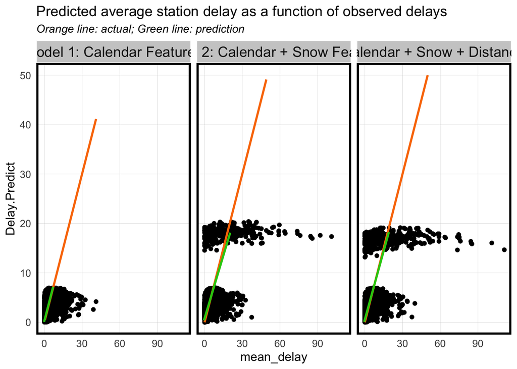

```r
allRegressions %>%
  dplyr::select(Delay.Predict, mean_delay, Regression) %>%
  ggplot(aes(mean_delay, Delay.Predict)) +
  geom_point() +
  stat_smooth(aes(mean_delay, mean_delay),
              method = "lm", se = FALSE, size = 1, colour="#FA7800") +
  stat_smooth(aes(Delay.Predict, mean_delay),
              method = "lm", se = FALSE, size = 1, colour="#25CB10") +
  facet_wrap(~Regression) +
  ylim(0,50)+
  labs(title="Predicted average station delay as a function of observed delays",
       subtitle="Orange line: actual; Green line: prediction") +
  plotTheme()
```

# 7 Additional Analyses